# **NOTE:** Use File > Save a copy in Drive to make a copy before doing anything else

# Project 7: Data Exploration and Visualization

### Overview

In this project, you will apply data exploration and visualization techniques to a real-world dataset of your choice. You'll practice using pandas for data analysis and create meaningful visualizations to gain insights from your data. This project builds on your Python programming skills while introducing you to the exciting world of data science.

In [Lab7](https://colab.research.google.com/drive/15QvSh0csZaCU-OuuPIfpWx5wLDDjmqK4?usp=sharing), you explore the titanic dataset and you should use it as a sample and pick a dataset of your interest to do a similar data exploration and visualization.

### Project Objectives

- Find and select a dataset from a real-world data source
- Formulate a clear inquiry question based on your chosen dataset
- Perform exploratory data analysis using pandas functions
- Create at least two meaningful data visualizations
- Analyze your findings and answer your inquiry question
- Reflect on the insights gained through data exploration

### Data Sources

You can choose from various online data sources such as:

- [Kaggle](https://www.kaggle.com/datasets) - Wide variety of datasets
- [data.gov](https://www.data.gov/) - U.S. government data
- [Our World in Data](https://ourworldindata.org/) - Global development data
- [GitHub](https://github.com/datasets) - Curated datasets
- [Google Dataset Search](https://datasetsearch.research.google.com/) - Search for datasets
- Or any other reliable data source you find interesting

## Part 1: Dataset Selection and Initial Exploration

#### TODO Tasks:

1. Select Your Dataset: Choose a dataset that interests you. Make sure it has at least 100 rows and multiple columns with different data types (e.g., numerical, categorical, dates).

Please create either text or code cells in between the TODO tasks to do the work.

I've been building characters in the video game Genshin Impact lately, and I wanted to analyse which characters I should add to my team. I want characters with uncommon features. I downloaded the CSV from Kaggle at this link [source](https://www.kaggle.com/datasets/sophiahealy/genshin-impact-character-data?resource=download)

2. Import Libraries: Import the necessary libraries (pandas, matplotlib, seaborn) at the beginning of your notebook by creating code cells below this text cell.
3. Load Your Data: Load your chosen dataset using pandas and save it to a pandas dataframe. Please create a code cell below this text cell to do it.

```python
import pandas as pd


import matplotlib.pyplot as plt
import seaborn as sns

df = pd.read_csv('genshin.csv', encoding='latin-1')
```

```python
df.head()
```

|  | character_name | rarity | region | vision | arkhe | weapon_type | model | constellation | birthday | special_dish | ... | hp_1_20 | atk_1_20 | def_1_20 | spsecial_0 | special_1 | special_2 | special_3 | special_4 | special_5 | special_6 |
| --- | --- | --- | --- | --- | --- | --- | --- | --- | --- | --- | --- | --- | --- | --- | --- | --- | --- | --- | --- | --- | --- |
| 0 | Albedo | 5 | Mondstadt | Geo | NaN | Sword | Medium Male | Princeps Cretaceus | 13-Sep | Woodland Dream | ... | 1030 | 20 | 68 | 0.0% | 0.0% | 7.2% | 14.4% | 14.4% | 21.6% | 28.8% |
| 1 | Alhaitham | 5 | Sumeru | Dendro | NaN | Sword | Tall Male | Vultur Volans | 11-Feb | Ideal Circumstance | ... | 1039 | 24 | 60 | 0.0% | 0.0% | 7.2% | 14.4% | 14.4% | 21.6% | 28.8% |
| 2 | Aloy | 5 | NaN | Cryo | NaN | Bow | Medium Female | Nora Fortis | 4-Apr | Satiety Gel | ... | 848 | 18 | 53 | 0.0% | 0.0% | 7.2% | 14.4% | 14.4% | 21.6% | 28.8% |
| 3 | Amber | 4 | Mondstadt | Pyro | NaN | Bow | Medium Female | Lepus | 10-Aug | Outrider's Champion Steak! | ... | 793 | 19 | 50 | 0.0% | 0.0% | 6.0% | 12.0% | 12.0% | 18.0% | 24.0% |
| 4 | Arataki Itto | 5 | Inazuma | Geo | NaN | Claymore | Tall Male | Taurus Iracundus | 1-Jun | Way of the Strong | ... | 1001 | 18 | 75 | 0.0% | 0.0% | 4.8% | 9.6% | 9.6% | 14.4% | 19.2% |

5 rows × 81 columns

4. Data Summary: Use the following functions to do inital exploration your dataset:
- info() - Display information about the dataset structure
- describe() - Show statistical summary of numerical columns
- head() - Display the first 5 rows (df.head())
- shape - Show the dimensions of the dataset (e.g. df.shape)
- columns - Get the column names (e.g. df.columns)

You may use 5 code cells below this text cell to accomplish it.

```python
df.describe()
```

|  | rarity | hp_90_90 | atk_90_90 | def_90_90 | hp_80_90 | atk_80_90 | def_80_90 | hp_80_80 | atk_80_80 | def_80_80 | ... | def_40_40 | hp_20_40 | atk_20_40 | def_20_40 | hp_20_20 | atk_20_20 | def_20_20 | hp_1_20 | atk_1_20 | def_1_20 |
| --- | --- | --- | --- | --- | --- | --- | --- | --- | --- | --- | --- | --- | --- | --- | --- | --- | --- | --- | --- | --- | --- |
| count | 84.000000 | 84.000000 | 84.000000 | 84.000000 | 84.000000 | 84.000000 | 84.000000 | 84.000000 | 84.000000 | 84.000000 | ... | 84.000000 | 84.000000 | 84.000000 | 84.000000 | 84.000000 | 84.000000 | 84.000000 | 84.000000 | 84.000000 | 84.000000 |
| mean | 4.559524 | 11726.047619 | 244.178571 | 698.297619 | 11015.273810 | 227.190476 | 649.547619 | 10369.952381 | 215.904762 | 617.511905 | ... | 286.976190 | 3207.797619 | 66.690476 | 191.047619 | 2449.785714 | 50.988095 | 145.964286 | 950.416667 | 19.523810 | 56.416667 |
| std | 0.499426 | 1645.152792 | 50.754348 | 91.541126 | 1884.017218 | 47.034844 | 85.113164 | 1441.360367 | 44.513331 | 80.677925 | ... | 36.451644 | 420.328666 | 13.075293 | 24.447093 | 305.083637 | 9.766545 | 18.507209 | 116.460677 | 3.585366 | 7.224804 |
| min | 4.000000 | 9189.000000 | 106.000000 | 499.000000 | 8553.000000 | 99.000000 | 464.000000 | 8144.000000 | 94.000000 | 440.000000 | ... | 200.000000 | 2555.000000 | 29.000000 | 134.000000 | 1978.000000 | 21.000000 | 100.000000 | 763.000000 | 8.000000 | 38.000000 |
| 25% | 4.000000 | 10500.500000 | 212.000000 | 630.000000 | 9761.750000 | 198.000000 | 585.000000 | 9265.000000 | 188.000000 | 556.000000 | ... | 261.750000 | 2864.500000 | 59.000000 | 172.750000 | 2198.500000 | 46.000000 | 131.250000 | 847.000000 | 18.000000 | 50.750000 |
| 50% | 5.000000 | 11146.500000 | 230.000000 | 683.000000 | 10374.500000 | 214.000000 | 635.000000 | 9878.500000 | 203.500000 | 605.000000 | ... | 284.000000 | 3099.000000 | 63.000000 | 190.000000 | 2401.000000 | 48.000000 | 147.000000 | 951.000000 | 19.000000 | 57.000000 |
| 75% | 5.000000 | 12925.500000 | 287.000000 | 759.250000 | 12017.000000 | 267.000000 | 706.000000 | 11404.250000 | 253.000000 | 671.500000 | ... | 313.000000 | 3479.750000 | 77.000000 | 208.250000 | 2652.750000 | 58.000000 | 159.250000 | 1030.000000 | 21.250000 | 62.000000 |
| max | 5.000000 | 15674.000000 | 349.000000 | 959.000000 | 21080.000000 | 325.000000 | 892.000000 | 13829.000000 | 308.000000 | 846.000000 | ... | 386.000000 | 4211.000000 | 94.000000 | 258.000000 | 3165.000000 | 79.000000 | 194.000000 | 1220.000000 | 27.000000 | 75.000000 |

8 rows × 43 columns

```python
df.info()
```

```
<class 'pandas.core.frame.DataFrame'>
RangeIndex: 84 entries, 0 to 83
Data columns (total 81 columns):
 #   Column               Non-Null Count  Dtype
---  ------               --------------  -----
 0   character_name       84 non-null     object
 1   rarity               84 non-null     int64
 2   region               73 non-null     object
 3   vision               84 non-null     object
 4   arkhe                9 non-null      object
 5   weapon_type          84 non-null     object
 6   model                84 non-null     object
 7   constellation        84 non-null     object
 8   birthday             84 non-null     object
 9   special_dish         73 non-null     object
```

[output cut: 73 more lines]

```python
df.columns
```

```
Index(['character_name', 'rarity', 'region', 'vision', 'arkhe', 'weapon_type',
       'model', 'constellation', 'birthday', 'special_dish', 'affiliation',
       'release_date', 'limited', 'voice_eng', 'voice_cn', 'voice_jp',
       'voice_kr', 'ascension', 'ascension_specialty', 'ascension_material',
       'ascension_boss', 'talent_material', 'talent_book_1-2',
       'talent_book_2-3', 'talent_book_3-4', 'talent_book_4-5',
       'talent_book_5-6', 'talent_book_6-7', 'talent_book_7-8',
       'talent_book_8-9', 'talent_book_9-10', 'talent_weekly', 'hp_90_90',
       'atk_90_90', 'def_90_90', 'hp_80_90', 'atk_80_90', 'def_80_90',
       'hp_80_80', 'atk_80_80', 'def_80_80', 'hp_70_80', 'atk_70_80',
       'def_70_80', 'hp_70_70', 'atk_70_70', 'def_70_70', 'hp_60_70',
       'atk_60_70', 'def_60_70', 'hp_60_60', 'atk_60_60', 'def_60_60',
       'hp_50_60', 'atk_50_60', 'def_50_60', 'hp_50_50', 'atk_50_50',
       'def_50_50', 'hp_40_50', 'atk_40_50', 'def_40_50', 'hp_40_40',
       'atk_40_40', 'def_40_40', 'hp_20_40', 'atk_20_40', 'def_20_40',
       'hp_20_20', 'atk_20_20', 'def_20_20', 'hp_1_20', 'atk_1_20', 'def_1_20',
       'spsecial_0', 'special_1', 'special_2', 'special_3', 'special_4',
       'special_5', 'special_6'],
      dtype='object')
```

```python
df.shape
```

```
(84, 81)
```

5. Inquiry Question: Write a clear, specific question that you want to answer using your dataset by creating a text cell below and **write the question in bold please.**

For example:

- "How has the average temperature changed in major cities over the past decade?"
- "What factors are most strongly correlated with housing prices?"
- "Is there a relationship between education level and income?"
- What is the average DEF at 'def_90_90' of characters with a Geo vision?
- What is the average HP at 'hp_90_90' of characters with a Hydro vision?

## Part 2: Data Visualization and Analysis

```python
avg_def_by_vision = df.groupby('vision')['def_90_90'].mean().reset_index()
```

```
([0, 1, 2, 3, 4, 5, 6],
 [Text(0, 0, 'Anemo'),
```

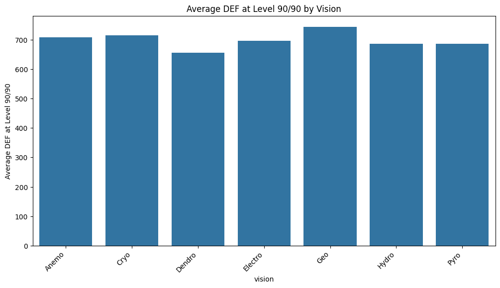

```python
plt.figure(figsize=(12, 6))
sns.barplot(x='vision', y='def_90_90', data=avg_def_by_vision)
plt.title('Average DEF at Level 90/90 by Vision')
plt.xlabel('vision')
plt.ylabel('Average DEF at Level 90/90')
plt.xticks(rotation=45, ha='right') # Rotate x-axis labels for better readability plt.tight_layout() # Adjust layout to prevent labels overlapping plt.show()
```

```
([0, 1, 2, 3, 4, 5, 6],
 [Text(0, 0, 'Anemo'),
```

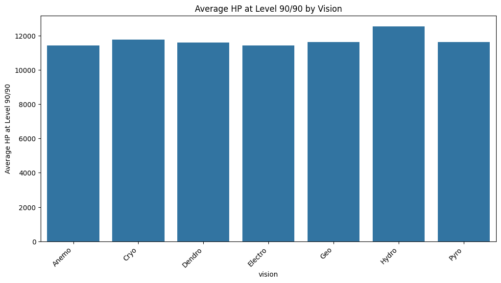

```python
plt.figure(figsize=(12, 6))
sns.barplot(x='vision', y='hp_90_90', data=avg_hp_by_vision)
plt.title('Average HP at Level 90/90 by Vision')
plt.xlabel('vision')
plt.ylabel('Average HP at Level 90/90')
plt.xticks(rotation=45, ha='right') # Rotate x-axis labels for better readability plt.tight_layout() # Adjust layout to prevent labels overlapping plt.show()
```

As expected, Hydro characters have higher base HP at level 90, and Geo characters have higher base DEF at level 90.

```python
counts = df.groupby(['region', 'vision']).size()

heatmap_data = counts.unstack(fill_value=0) # fill_value=0 ensures missing combinations are shown as 0
```

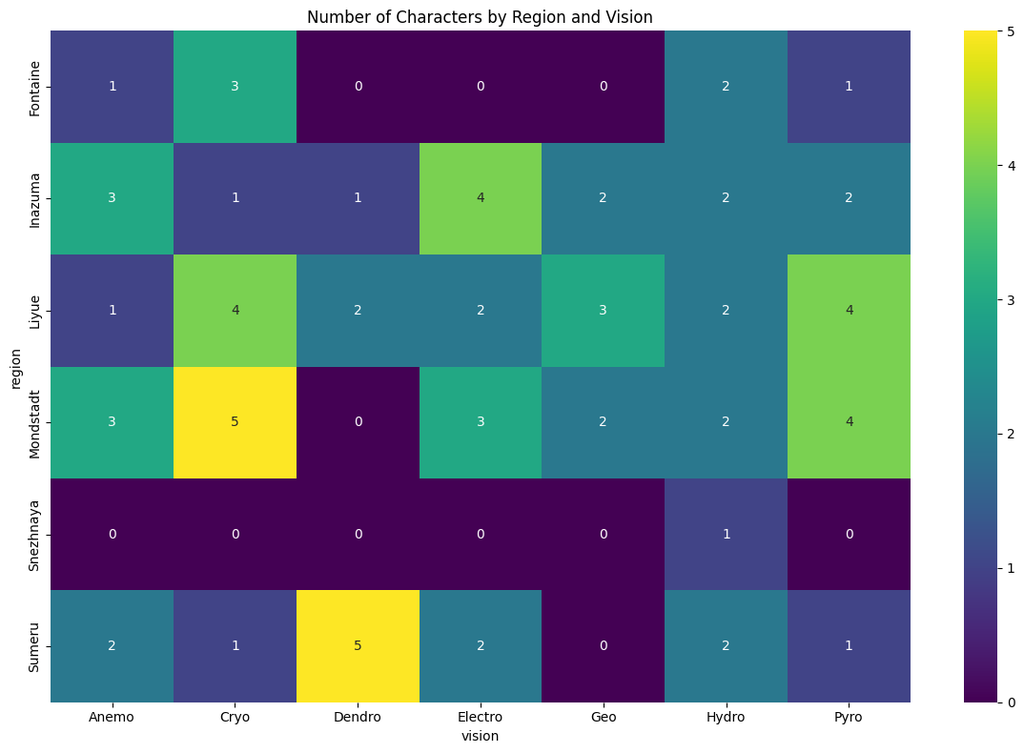

```python
plt.figure(figsize=(12, 8)) # Adjust figure size as needed
sns.heatmap(heatmap_data, annot=True, fmt='d', cmap='viridis') # annot=True shows values, fmt='d' formats as integer
plt.title('Number of Characters by Region and Vision')
plt.xlabel('vision')
plt.ylabel('region')
plt.tight_layout() # Adjust layout to prevent labels overlapping plt.show()
```

This is a heatmap showing vision by region. We can see that Sumeru has a huge amount of Dendro characters at 5, and Mondstadt has a huge amount of Cryo characters at 5 as well. This makes sense for Sumeru, with the patch the Dendro element was released in being the same as the one this region was released.

We also see a darkness for Snezhnaya, owing to the fact that only one Snezhnaya character had been released at the time the data was collected.

Surprises:

I was surprised to see that Mondstadt had so many Cryo characters, given that it's the nation of Anemo.

I was also surprised to see that Dendro characters have lower-than-average DEF. This could be because they are a recent addition, and DEF has become less-and-less relevant to the meta of the game as time has gone on. It could also be because Dendro characters need both ATK and EM, while most characters of other elements don't need EM.

#### TODO Tasks:

1. Data Cleaning (if necessary): Check for and handle any missing values, duplicates, or data quality issues.

**NOTE: This could be a daunting task even for seasoned data scientists. My suggestion is to use a dataset that is already clean if you can for the purpose of completing this assignment in a week.**

Examples:

- Checking for missing values: df.isnull().sum()
- Dropping rows with any missing values: df.dropna(inplace=True)
- Dropping columns with all missing values: df.dropna(axis=1, how='all', inplace=True)
- Removing duplicate row: df.drop_duplicates(inplace=True)
2. Create Visualizations: Create at least 2 different types of visualizations that help answer your research question. Choose from:
- Bar charts
- Line plots
- Scatter plots
- Histograms
- Box plots
- Heatmaps
- Any other appropriate visualization
3. Customize Your Plots: Make sure your visualizations are clear and informative by:
- Adding appropriate titles
- Labeling axes
- Using colors effectively
- Adding legends when necessary

Please create code cells below this to create your visualizations.

4. Analysis: Write 1-2 paragraphs discussing:
- Whether your research question can be answered with the available data
- What insights you discovered through your visualizations
- Any unexpected or interesting findings
- Limitations of your analysis
- Suggestions for further investigation

Please create a text cell below this cell to write your analysis.

## NOTE: If you use a local dataset, you MUST submit the dataset along with your notebook to get credit.

- Download your notebook as CS110_Project7.ipynb
- Ensure all TODO tasks are completed
- Make sure your code runs without errors
- Include clear comments explaining your work
- Submit the notebook file

## Grading Criteria (4 points)

- Dataset Selection: Appropriate choice of dataset with sufficient complexity
- Inquiry Question: Clear, specific, and answerable with the chosen data
- Data Exploration: Proper use of pandas functions for initial analysis
- Visualizations: At least 2 clear, well-formatted, and relevant plots
- Analysis: Thoughtful interpretation of findings and answer to research question
- Code Quality: Clean, commented, and well-organized code

Remember: The goal is not just to create visualizations, but to use them to gain meaningful insights about your data. Think like a data scientist and let your curiosity guide your exploration!